### Differences from the first submission:

- Excercise 7, 8, 9 solved

```python
#Ignore warnings caused by function fitting
import warnings
warnings.filterwarnings('ignore')
```

# Statistical analysis of water discharge of surface streams

### Task:

- find a dataset about a river's water level
- analyse the various timeseries data by fitting the right/suitable distribution onto it.
- draw some conclusions about the weather near the river/measurement station

### A list of statistical distributions

- Each hyperlink directs to the corresponding Wikipedia page of the provided distribution.
- PMF: probabitity mass function (for discreted distribution)
- PDF: probabitity density function (for countinuous distribution)

**[Fermi-Dirac statistics](https://en.wikipedia.org/wiki/Fermi-Dirac_statistics)** $$ \bar{n}_i = \frac{1}{e^{(\varepsilon_i - \mu) / k_\text{B} T} + 1} $$

**[Bose-Einstein statistics](https://en.wikipedia.org/wiki/Bose%E2%80%93Einstein_statistics)** $$ \bar{n}_i = \frac{g_i}{e^{(\varepsilon_i-\mu) / k_\text{B} T} - 1} $$

**[Maxwell-Boltzmann distribution](https://en.wikipedia.org/wiki/Maxwell-Boltzmann_distribution)** $$ \text{PDF} = \sqrt{\frac{2}{\pi}} \, \frac{x^2}{a^3} \, \exp\left(\frac{-x^2}{2a^2} \right) $$

**[Planck’s law](https://en.wikipedia.org/wiki/Planck%E2%80%99s_law)** $$ u_\nu(\nu, T) = \frac{ 8 \pi h \nu^3}{c^3} \frac 1{\exp\left(\frac{h\nu}{k_\mathrm B T}\right) - 1} $$

**[Binomial distribution](https://en.wikipedia.org/wiki/Binomial_distribution)**

- discrete variables
- number of successes of n independent experiments $$ \text{PMF} = \binom{n}{k} p^k q^{n-k} $$

**[Cauchy distribution](https://en.wikipedia.org/wiki/Cauchy_distribution)**

- ration of normally distributed variables
- shape of spectral lines $$ \text{PDF} = \frac{1}{\pi\gamma\,\left[1 + \left(\frac{x-x_0}{\gamma}\right)^2\right]}\! $$

**[Gamma distribution](https://en.wikipedia.org/wiki/Gamma_distribution)** $$ \text{PDF} = \frac{1}{\Gamma(k) \theta^k} x^{k - 1} e^{-x/\theta}$$

**[Geometric distribution](https://en.wikipedia.org/wiki/Geometric_distribution)**

- number of trials before the first success in Bernoulli trials $$ \text{PDF} = (1 - p)^{k-1}p $$

**[Chi-squared distribution](https://en.wikipedia.org/wiki/Chi-squared_distribution)**

- sum of squares of independent standard normal variables
- how to construct confidence intervals $$ \text{PDF} = \frac{1}{2^{k/2}\Gamma(k/2)}\; x^{k/2-1} e^{-x/2}\; $$

**[Exponential distribution](https://en.wikipedia.org/wiki/Exponential_distribution)** $$ \text{PDF} = \lambda e^{-\lambda x} $$

**[Gumbel distribution](https://en.wikipedia.org/wiki/Gumbel_distribution)**

- expectation value of the maximum/minimum of samples drawn from a parent distribution with exp tail $$ \text{PDF} = \frac{1}{\beta}e^{-(z+e^{-z})} $$ where $z=\frac{x-\mu}{\beta}$

**[Lévy distribution](https://en.wikipedia.org/wiki/L%C3%A9vy_distribution)**

- heavy-tailed distribution $$ \text{PDF} = \sqrt{\frac{c}{2\pi}}~~\frac{e^{-\frac{c}{2(x-\mu)}}}{(x-\mu)^{3/2}} $$

**[Logistic distribution](https://en.wikipedia.org/wiki/Logistic_distribution)**

- categorical dependent variables
- logistic regression $$ \text{PDF} = \frac{e^{-(x-\mu)/s}} {s\left(1+e^{-(x-\mu)/s}\right)^2} $$

**[Log normal distribution](https://en.wikipedia.org/wiki/Log_normal_distribution)**

- product of many independent variables
- size distribution of particles $$ \frac{ 1 }{\ x\sigma\sqrt{2\pi\ }\ }\ \exp\left( - \frac{ \left( \ln x - \mu\ \right)^2}{ 2 \sigma^2 } \right) $$

**[Normal distribution](https://en.wikipedia.org/wiki/Normal_distribution)** $$ \text{PDF} = \frac{1}{\sigma\sqrt{2\pi}} e^{-\frac{1}{2}\left(\frac{x - \mu}{\sigma}\right)^2}$$

**[Pareto distribution](https://en.wikipedia.org/wiki/Pareto_distribution)**

- heavy-tailed, decreasing power-law
- degree distribution of social networks $$ \text{PDF} = \frac{\alpha x_\mathrm{m}^\alpha}{x^{\alpha+1}} $$

**[Poisson distribution](https://en.wikipedia.org/wiki/Poisson_distribution)** $$ \text{PMF} = \frac{\lambda^{k}e^{-\lambda}}{k!} $$

**[Student t-distribution](https://en.wikipedia.org/wiki/Student%27s_t-distribution)**

- average of a normally distributed population
- n is small $$ \text{PDF} = \frac{\Gamma \left(\frac{\ \nu+1\ }{ 2 } \right)} {\sqrt{\pi\ \nu\ }\ \Gamma \left(\frac{ \nu }{\ 2\ } \right)}\ \left(\ 1 + \frac{~ x^2\ }{ \nu }\ \right)^{-\frac{\ \nu+1\ }{ 2 }}$$

**[Continuous Uniform distribution](https://en.wikipedia.org/wiki/Continuous_uniform_distribution)** $$ \text{PDF} = \begin{cases} \frac{1}{b-a} & \text{for } x \in [a,b] \\ 0 & \text{otherwise} \end{cases}$$

**[Weibull distribution](https://en.wikipedia.org/wiki/Weibull_distribution)**

- any of n iid variables being above a certain limit
- first failure of a system of n identical components $$ \text{PDF} = \begin{cases} \frac{k}{\lambda}\left(\frac{x}{\lambda}\right)^{k-1}e^{-(x/\lambda)^k}, & x\geq0,\\ 0, & x<0.\end{cases} $$

```python
# packages
import os
import numpy as np
import pandas as pd
import matplotlib.pyplot as plt
import seaborn as sns

from scipy.optimize import curve_fit
from scipy.signal import find_peaks

from scipy.stats import cauchy, gamma, chi2, expon, gumbel_l, levy, logistic, lognorm, norm, pareto, t, weibull_min
distribution = [cauchy, gamma, chi2, expon, gumbel_l, levy, logistic, lognorm, norm,  pareto, t, weibull_min]
distribution_names = ['Cauchy', 'Gamma', '$\chi^2$', 'Exponential', 'Gumbel', 'Lévy', 'Logistic', 'Log normal', 'Normal', 'Pareto', 'Student-t', 'Weibull']

FS = 15 # fontsize for plot


# Fitting functions
def exponential(x, l1, l2, c):
    return l1 * np.exp(-l2*x) + c

def lin(x, a, b):
    return a*x + b
```

## Excercise 1

For the purposes of the current excercises, select a stream from a rainy area with relatively small discharge so that the effect of short but strong storms is visible. Good choices are small rivers from the north-eastern US, e.g. site 01589440. Retrieve at least 10 years of data.

Large amounts of historical surface water data are available from the United States Geological Survey (USGS) at https://waterdata.usgs.gov/nwis The goal of the project is to retrieve samples from the web interface manually, and then later automate the process by calling the web service as described at https://help.waterdata.usgs.gov/faq/automated-retrievals.

The service is explained in more detail here: https://waterservices.usgs.gov/rest/Site-Service.html

The location: [Jones Falls at Sorrento](https://waterdata.usgs.gov/monitoring-location/01589440/#parameterCode=00065&period=P7D&showMedian=false)

```python
# Download data with a given time period
start_date = ['2010', '01', '01']
end_date   = ['2019', '12', '31']

filename = f"./data/jones_falls_{''.join(start_date)}-{''.join(end_date)}.txt"

if not os.path.exists(filename):
    import requests
    url = "https://nwis.waterdata.usgs.gov/nwis/uv/"
    params = {
        "format": 'rdb',
        "site_no": '01589440',
        "parameterCd": '00065',
        "begin_date": ''.join(start_date),
        "end_date": ''.join(end_date),
        "siteStatus": 'all'
    }
    response = requests.get(url, params=params)

    with open(filename, "w") as file:
        file.write(response.text)
    df = pd.read_csv(filename, sep='\t', skiprows=[30], comment='#', parse_dates=['datetime'])

else:
    df = pd.read_csv(filename, sep='\t', skiprows=[30], comment='#', parse_dates=['datetime'])

df.head()
```

|  | agency_cd | site_no | datetime | tz_cd | 69744_00060 | 69744_00060_cd | 69745_00065 | 69745_00065_cd |
| --- | --- | --- | --- | --- | --- | --- | --- | --- |
| 0 | USGS | 1589440 | 2010-01-01 00:00:00 | EST | 58.2 | A | 3.87 | A |
| 1 | USGS | 1589440 | 2010-01-01 00:15:00 | EST | 58.2 | A | 3.87 | A |
| 2 | USGS | 1589440 | 2010-01-01 00:30:00 | EST | 59.3 | A | 3.88 | A |
| 3 | USGS | 1589440 | 2010-01-01 00:45:00 | EST | 59.3 | A | 3.88 | A |
| 4 | USGS | 1589440 | 2010-01-01 01:00:00 | EST | 59.3 | A | 3.89 | A |

## Excercise 2

Load the downloaded data file into the processing environment paying attention to handling time stamps and perfoming the necessary data type conversions (converting dates to floating point numbers such as unix time stamp or julian date sometimes makes handling time series easier).

Plot the data for a certain interval to show that the effect of storms is clearly visible!

```python
df = df[['datetime', '69744_00060', '69745_00065']]
df.dropna(inplace=True)
df.rename(columns={'datetime':'date', '69744_00060':'water_discharge', '69745_00065':'gage_height'}, inplace=True)
df['date'] = df['date'].astype('datetime64[s]')
df.head()
```

|  | date | water_discharge | gage_height |
| --- | --- | --- | --- |
| 0 | 2010-01-01 00:00:00 | 58.2 | 3.87 |
| 1 | 2010-01-01 00:15:00 | 58.2 | 3.87 |
| 2 | 2010-01-01 00:30:00 | 59.3 | 3.88 |
| 3 | 2010-01-01 00:45:00 | 59.3 | 3.88 |
| 4 | 2010-01-01 01:00:00 | 59.3 | 3.89 |

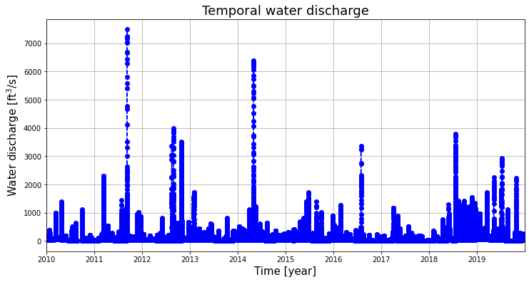

```python
# Water discharge
plt.figure(figsize=(12,6))
plt.plot(df.date, df.water_discharge, 'o--', c='b')
plt.xlim(np.min(df.date), np.max(df.date))
plt.title('Temporal water discharge', fontsize=FS+3)
plt.xlabel('Time [year]', fontsize=FS)
plt.ylabel('Water discharge [ft$^3/$s]', fontsize=FS)
plt.grid()
plt.show()
```

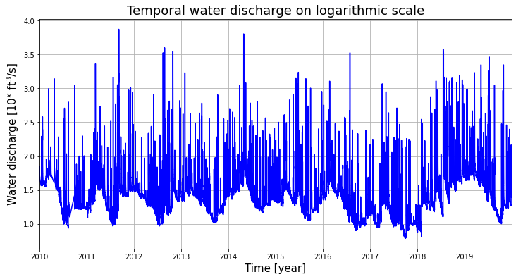

```python
# Water discharge - log scale
plt.figure(figsize=(12,6))
plt.plot(df.date, np.log10(df.water_discharge), '-', c='b')
plt.xlim(np.min(df.date), np.max(df.date))
plt.title('Temporal water discharge on logarithmic scale', fontsize=FS+3)
plt.xlabel('Time [year]', fontsize=FS)
plt.ylabel('Water discharge [$10^x$ ft$^3/$s]', fontsize=FS)
plt.grid()
plt.show()
```

## Excercise 3

Plot the histogram of water discharge values. Fit the data with an appropriate distribution function and bring arguments in favor of the choice of function!

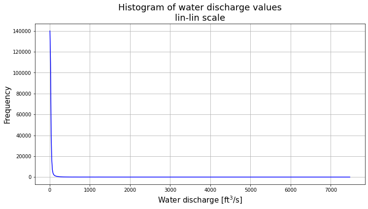

```python
# Histogram
hist, bins = np.histogram(df.water_discharge, bins=500)
bins = bins[:-1]

plt.figure(figsize=(12,6))
plt.plot(bins, hist, '-', c='b')
plt.title('Histogram of water discharge values\nlin-lin scale', fontsize=FS+3)
plt.xlabel('Water discharge [ft$^3/$s]', fontsize=FS)
plt.ylabel('Frequency', fontsize=FS)
plt.grid()
plt.show()
```

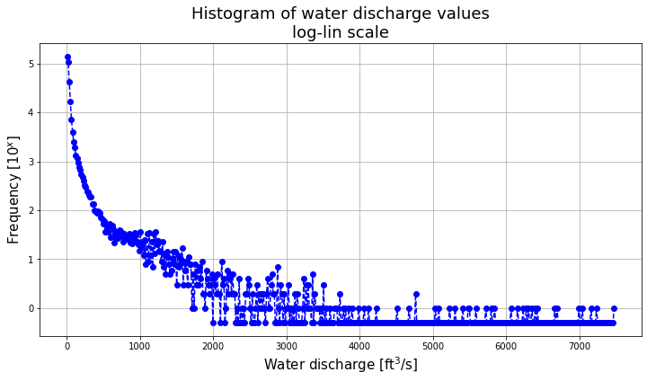

```python
hist_log = hist.astype('float64')
hist_log[hist_log == 0] += 5*1e-1
hist_log = np.log10(hist_log)

plt.figure(figsize=(12,6))
plt.plot(bins, hist_log, 'o--', c='b')
plt.title('Histogram of water discharge values\nlog-lin scale', fontsize=FS+3)
plt.xlabel('Water discharge [ft$^3/$s]', fontsize=FS)
plt.ylabel('Frequency [$10^x$]', fontsize=FS)
plt.grid()
plt.show()
```

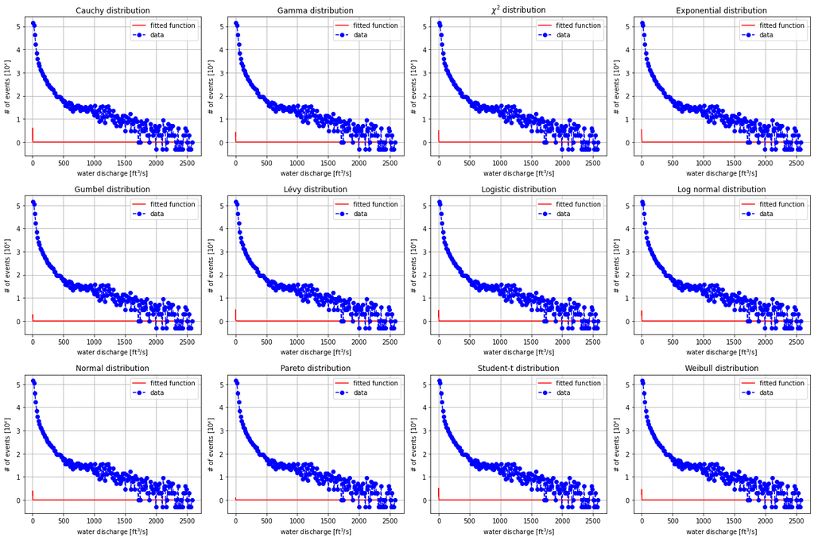

```python
# Fitting functions
y_max_boundary = 2600
idx = np.where(bins <= y_max_boundary)[0][-1]
x_axis = np.linspace(0, bins[idx], y_max_boundary)

fit_params = []
fitted_data = []

fig, ax = plt.subplots(3, 4, figsize=(18, 12))
for i, dist in enumerate(distribution):
    params = dist.fit(hist_log[:idx])
    fit_params.append(params)
    fitted_data.append(dist.pdf(x_axis, *params))
    row = i // 4
    col = i % 4
    ax[row, col].plot(x_axis, fitted_data[i], c='r', label='fitted function')
    ax[row, col].plot(bins[:idx], hist_log[:idx], 'o--', c='b', label='data')
    ax[row, col].set_title(distribution_names[i]+' distribution')
    ax[row, col].set_xlabel('water discharge [ft$^3$/s]')
    ax[row, col].set_ylabel('# of events [$10^x$]')
    ax[row, col].legend()
    ax[row, col].grid()
plt.tight_layout()
plt.show()
```

```python
fit_params_scientific = [["{:.2e}".format(num) for num in tup] for tup in fit_params]

print('Fit params:')
for i, name, in enumerate(distribution_names):
    print(f"{name} distribution: \t", end='')
    for j in fit_params_scientific[i]:
        print(f"{j}", end=', ')
    print()
```

```
Fit params:
Cauchy distribution: 	1.08e+00, 5.14e-01,
Gamma distribution: 	4.06e+00, -7.96e-01, 4.97e-01,
$\chi^2$ distribution: 	6.13e-01, -3.01e-01, 1.71e+00,
Exponential distribution: 	-3.01e-01, 1.52e+00,
Gumbel distribution: 	1.77e+00, 1.31e+00,
Lévy distribution: 	-4.37e-01, 8.47e-01,
Logistic distribution: 	1.13e+00, 5.31e-01,
Log normal distribution: 	3.41e-01, -1.63e+00, 2.69e+00,
Normal distribution: 	1.22e+00, 1.01e+00,
Pareto distribution: 	6.79e-02, -3.01e-01, 2.02e-07,
Student-t distribution: 	3.89e+00, 1.10e+00, 7.29e-01,
Weibull distribution: 	1.42e+00, -4.75e-02, 1.45e+00,
```

The above distributions does not fit well to the data. With a few more fitting parameters given to the exponential distribution, the result will be better.

```
Fit params:
Param_1 = 3.67273 \pm 0.10607
Param_2 = 0.00136 \pm 0.00011
Param_3 = 0.20343 \pm 0.08062
```

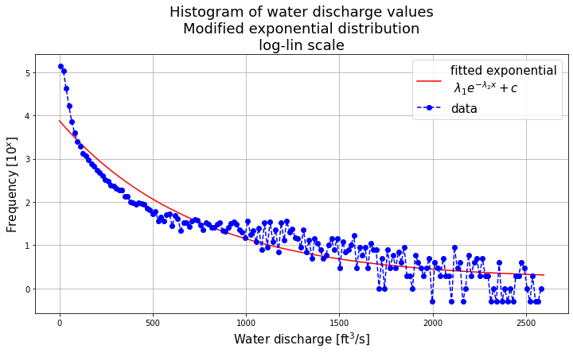

```python
popt_exp, pcov_exp = curve_fit(exponential,  bins[:idx], hist_log[:idx], p0=(5, 0.01, 0.3))
perr_exp = np.sqrt(np.diag(pcov_exp))
print('Fit params:')
for i, (opt, err) in enumerate(zip(popt_exp, perr_exp)):
    print(f"Param_{i+1} = {round(opt, 5)} \pm {round(err, 5)}")

plt.figure(figsize=(12,6))
plt.plot(x_axis, exponential(x_axis, *popt_exp), c='r', label='fitted exponential\n $\lambda_1 e^{-\lambda_2 x} + c$')
plt.plot(bins[:idx], hist_log[:idx], 'o--', c='b', label='data')
plt.title('Histogram of water discharge values\nModified exponential distribution\nlog-lin scale', fontsize=FS+3)
plt.xlabel('Water discharge [ft$^3/$s]', fontsize=FS)
plt.ylabel('Frequency [$10^x$]', fontsize=FS)
plt.legend(fontsize=FS)
plt.grid()
plt.show()
```

Let's use logarithmic x scale, and fit a linear to the data.

```
Fit params:
Param_1 = -2.09983 \pm 0.04424
Param_2 = 7.53967 \pm 0.12812
```

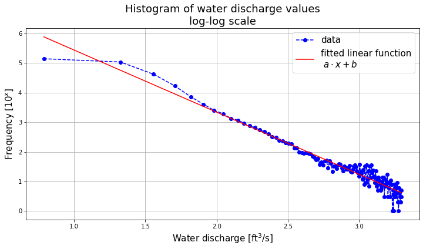

```python
first_zero = np.where(hist == 0)[0][0]

hist_log_2 = np.log10(hist[:first_zero])
bins_log_2 = np.log10(bins[:first_zero])
popt_lin, pcov_lin = curve_fit(lin, bins_log_2, hist_log_2)
perr_lin = np.sqrt(np.diag(pcov_lin))
print('Fit params:')
for i, (opt, err) in enumerate(zip(popt_lin, perr_lin)):
    print(f"Param_{i+1} = {round(opt, 5)} \pm {round(err, 5)}")

plt.figure(figsize=(12,6))
plt.plot(bins_log_2, hist_log_2, 'o--', c='b', label='data')
plt.plot(bins_log_2, lin(bins_log_2, *popt_lin), c='r', label='fitted linear function\n $a\cdot x+b$')
plt.title('Histogram of water discharge values\nlog-log scale', fontsize=FS+3)
plt.xlabel('Water discharge [ft$^3/$s]', fontsize=FS)
plt.ylabel('Frequency [$10^x$]', fontsize=FS)
plt.legend(fontsize=FS)
plt.grid()
plt.show()
```

## Excercise 4

In case of small streams, storms and passing weather fronts with rain can significantly increase water discharge on a short time scale. Develop a simple algorithm to detect rainy events in the data. Plot the original time series and mark rainy events!

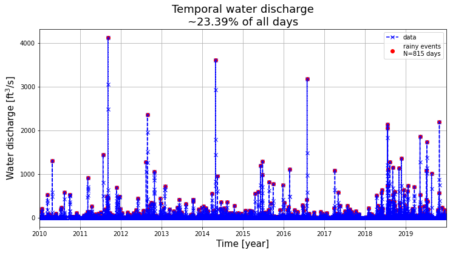

```python
t_diff_in_hours = 3 # hour

water_discharge_diff = np.round(abs(np.diff(df.water_discharge[::(t_diff_in_hours*4)])), 1)
dates_wd_diff = df.date[::(t_diff_in_hours*4)][:-1].values

dates_wd_diff_wo0 = dates_wd_diff[water_discharge_diff != 0]
# water_discharge_diff without zeros
water_discharge_diff_wo0 = water_discharge_diff[water_discharge_diff != 0]

                                                        # ˇ~~ only one peak per day
peaks = find_peaks(water_discharge_diff_wo0, height=2, distance=(24/t_diff_in_hours))

# Rainy days
rainy_days_pct = len(dates_wd_diff_wo0[peaks[0]])/(len(df.date)/(4*24))*100

plt.figure(figsize=(12,6))
plt.plot(dates_wd_diff_wo0, water_discharge_diff_wo0, 'x--', c='b', label='data')
plt.scatter(dates_wd_diff_wo0[peaks[0]], peaks[1]['peak_heights'], marker='o', color='r', label=f'rainy events\nN={len(dates_wd_diff_wo0[peaks[0]])} days')
plt.xlim(np.min(dates_wd_diff_wo0), np.max(dates_wd_diff_wo0))
plt.title(f'Temporal water discharge\n~{np.round(rainy_days_pct,2)}% of all days', fontsize=FS+3)
plt.xlabel('Time [year]', fontsize=FS)
plt.ylabel('Water discharge [ft$^3/$s]', fontsize=FS)
plt.legend()
plt.grid()
plt.show()
```

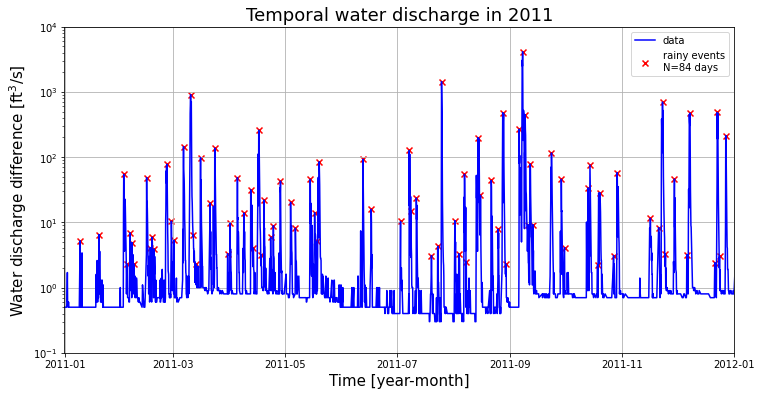

```python
# Find indices where year is after 2011 and before 2012
indices = np.where((dates_wd_diff_wo0.astype('datetime64[Y]') >= np.datetime64('2011')) & (dates_wd_diff_wo0.astype('datetime64[Y]') <= np.datetime64('2011')))[0]
peak_indices = np.where((dates_wd_diff_wo0[peaks[0]].astype('datetime64[Y]') >= np.datetime64('2011')) &
                        (dates_wd_diff_wo0[peaks[0]].astype('datetime64[Y]') <= np.datetime64('2011')))[0]

plt.figure(figsize=(12,6))
plt.plot(dates_wd_diff_wo0, water_discharge_diff_wo0, c='b', label='data')
plt.scatter(dates_wd_diff_wo0[peaks[0]], peaks[1]['peak_heights'], marker='x', color='r', label=f'rainy events\nN={len(peak_indices)} days')
plt.title('Temporal water discharge in 2011', fontsize=FS+3)
plt.xlabel('Time [year-month]', fontsize=FS)
plt.ylabel('Water discharge difference [ft$^3/$s]', fontsize=FS)
plt.xlim(dates_wd_diff_wo0[indices[0]-1], dates_wd_diff_wo0[indices[-1]+1])
plt.ylim(10**-1, 10**4 )
plt.yscale('log')
plt.legend()
plt.grid()
plt.show()
```

## Excercise 5

Water discharge increases significantly during rain producing maxima in the time series. Plot the distribution of maximum values and fit with an appropriate function. Bring arguments to support the choice of probabilistic model!

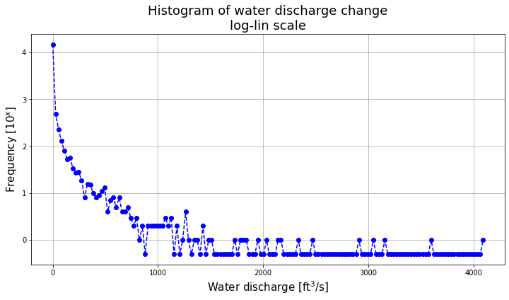

```python
# histrogram
hist_rain, bins_rain = np.histogram(water_discharge_diff_wo0, bins=150)
bins_rain = bins_rain[:-1]

hist_log_rain = hist_rain.astype('float64')
hist_log_rain[hist_log_rain == 0] += 5*1e-1
hist_log_rain = np.log10(hist_log_rain)

plt.figure(figsize=(12,6))
plt.plot(bins_rain, hist_log_rain, 'o--', c='b')
plt.title('Histogram of water discharge change\nlog-lin scale', fontsize=FS+3)
plt.xlabel('Water discharge [ft$^3/$s]', fontsize=FS)
plt.ylabel('Frequency [$10^x$]', fontsize=FS)
plt.grid()
plt.show()
```

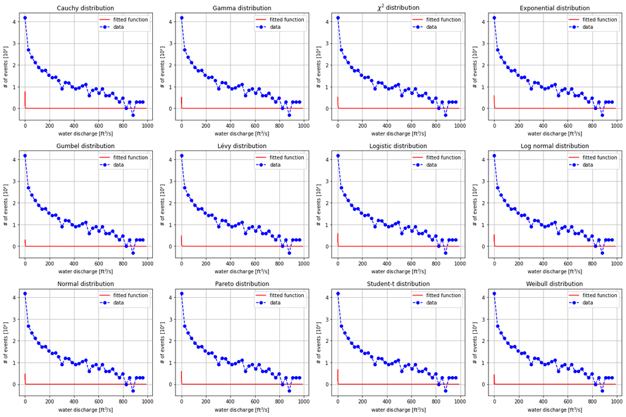

```python
y_max_boundary_2 = 1000
idx_2 = np.where(bins_rain <= y_max_boundary_2)[0][-1]
x_axis_2 = np.linspace(0, bins_rain[idx_2], y_max_boundary_2)

fit_params_2 = []
fitted_data_2 = []

fig, ax = plt.subplots(3, 4, figsize=(18, 12))
for i, dist in enumerate(distribution):
    params = dist.fit(hist_log_rain[:idx_2])
    fit_params_2.append(params)
    fitted_data_2.append(dist.pdf(x_axis_2, *params))
    row = i // 4
    col = i % 4
    ax[row, col].plot(x_axis_2, fitted_data_2[i], c='r', label='fitted function')
    ax[row, col].plot(bins_rain[:idx_2], hist_log_rain[:idx_2], 'o--', c='b', label='data')
    ax[row, col].set_title(distribution_names[i]+' distribution')
    ax[row, col].set_xlabel('water discharge [ft$^3$/s]')
    ax[row, col].set_ylabel('# of events [$10^x$]')
    ax[row, col].legend()
    ax[row, col].grid()
plt.tight_layout()
plt.show()
```

```python
fit_params_2_scientific = [["{:.2e}".format(num) for num in tup] for tup in fit_params_2]

print('Fit params:')
for i, name, in enumerate(distribution_names):
    print(f"{name} distribution: \t", end='')
    for j in fit_params_2_scientific[i]:
        print(f"{j}", end=', ')
    print()
```

```
Fit params:
Cauchy distribution: 	8.82e-01, 3.83e-01,
Gamma distribution: 	4.64e+00, -6.33e-01, 3.68e-01,
$\chi^2$ distribution: 	1.53e+00, -3.01e-01, 1.11e+00,
Exponential distribution: 	-3.01e-01, 1.38e+00,
Gumbel distribution: 	1.54e+00, 1.13e+00,
Lévy distribution: 	-4.02e-01, 9.15e-01,
Logistic distribution: 	9.82e-01, 4.26e-01,
Log normal distribution: 	3.57e-01, -1.10e+00, 2.04e+00,
Normal distribution: 	1.08e+00, 8.32e-01,
Pareto distribution: 	4.88e+07, -6.71e+07, 6.71e+07,
Student-t distribution: 	3.21e+00, 9.32e-01, 5.48e-01,
Weibull distribution: 	8.28e-01, 3.01e-01, 7.95e-01,
```

Once again the above distributions does not fit well to the data. Let's use the `exponential` function.

```
Fit params:
Param_1 = 2.93429 \pm 0.18276
Param_2 = 0.00427 \pm 0.00067
Param_3 = 0.3499 \pm 0.1132
```

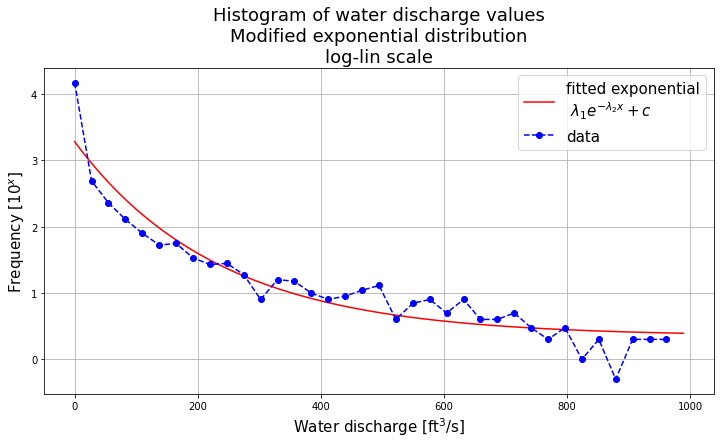

```python
popt_exp_rain, pcov_exp_rain = curve_fit(exponential, bins_rain[:idx_2], hist_log_rain[:idx_2], p0=(2, 0.005, 0.2))
perr_exp_rain = np.sqrt(np.diag(pcov_exp_rain))
print('Fit params:')
for i, (opt, err) in enumerate(zip(popt_exp_rain, perr_exp_rain)):
    print(f"Param_{i+1} = {round(opt, 5)} \pm {round(err, 5)}")

plt.figure(figsize=(12,6))
plt.plot(x_axis_2, exponential(x_axis_2, *popt_exp_rain), c='r', label='fitted exponential\n $\lambda_1 e^{-\lambda_2 x} + c$')
plt.plot(bins_rain[:idx_2], hist_log_rain[:idx_2], 'o--', c='b', label='data')
plt.title('Histogram of water discharge values\nModified exponential distribution\nlog-lin scale', fontsize=FS+3)
plt.xlabel('Water discharge [ft$^3/$s]', fontsize=FS)
plt.ylabel('Frequency [$10^x$]', fontsize=FS)
plt.legend(fontsize=FS)
plt.grid()
plt.show()
```

```
Fit params:
Param_1 = -1.06353 \pm 0.07161
Param_2 = 3.76738 \pm 0.18082
```

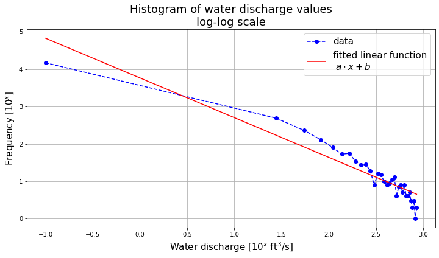

```python
first_zero_rain = np.where(hist_rain == 0)[0][0]

hist_log_rain_2 = np.log10(hist_rain[:first_zero_rain])
bins_log_rain = np.log10(bins_rain[:first_zero_rain])

popt_lin_rain, pcov_lin_rain = curve_fit(lin, bins_log_rain, hist_log_rain_2)
perr_lin_rain = np.sqrt(np.diag(pcov_lin_rain))
print('Fit params:')
for i, (opt, err) in enumerate(zip(popt_lin_rain, perr_lin_rain)):
    print(f"Param_{i+1} = {round(opt, 5)} \pm {round(err, 5)}")

plt.figure(figsize=(12,6))
plt.plot(bins_log_rain, hist_log_rain_2, 'o--', c='b', label='data')
plt.plot(bins_log_rain, lin(bins_log_rain, *popt_lin_rain), c='r', label='fitted linear function\n $a\cdot x+b$')
plt.title('Histogram of water discharge values\nlog-log scale', fontsize=FS+3)
plt.xlabel('Water discharge [$10^x$ ft$^3/$s]', fontsize=FS)
plt.ylabel('Frequency [$10^x$]', fontsize=FS)
plt.legend(fontsize=FS)
plt.grid()
plt.show()
```

## Excercise 6

Once rainy events are detected, plot the distribution of the length of sunny intervals between rains. Fit the distribution with an appropriate function!

```python
# Distances of rainy days
rainy_day_distances = np.array(np.diff(dates_wd_diff_wo0[peaks[0]]).astype('timedelta64[D]'), dtype='int')
```

```
Fit params:
Param_1 = 676.03949 \pm 26.20505
Param_2 = 0.49097 \pm 0.02491
Param_3 = 4.3538 \pm 2.13616
```

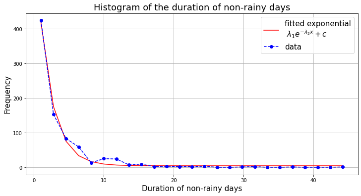

```python
hist_rainy_day_distances, bins_rainy_day_distances = np.histogram(rainy_day_distances, bins=25)
bins_rainy_day_distances = bins_rainy_day_distances[:-1]

popt_rainy_day_distances, pcov_rainy_day_distances = curve_fit(exponential, bins_rainy_day_distances, hist_rainy_day_distances)
perr_rainy_day_distances = np.sqrt(np.diag(pcov_rainy_day_distances))
print('Fit params:')
for i, (opt, err) in enumerate(zip(popt_rainy_day_distances, perr_rainy_day_distances)):
    print(f"Param_{i+1} = {round(opt, 5)} \pm {round(err, 5)}")

plt.figure(figsize=(12,6))
plt.plot(bins_rainy_day_distances, exponential(bins_rainy_day_distances, *popt_rainy_day_distances), c='r', label='fitted exponential\n $\lambda_1 e^{-\lambda_2 x} + c$')
plt.plot(bins_rainy_day_distances, hist_rainy_day_distances, 'o--', c='b', label='data')
plt.title("Histogram of the duration of non-rainy days", fontsize=FS+3)
plt.xlabel('Duration of non-rainy days', fontsize=FS)
plt.ylabel('Frequency', fontsize=FS)
plt.legend(fontsize=FS)
plt.grid()
plt.show()
```

## Excercise 7

What is the maximum of water discharge in an arbitrarily chosen period of one year? Calculate the maximum of water discharge due to rain in a rolling window of 1 year, plot its distribution and fit with an appropriate function!

```python
window_size = sum(df['date'] < pd.to_datetime("1/1/2011"))
roll_year = np.lib.stride_tricks.sliding_window_view(df['water_discharge'], window_size).max(axis=1)
```

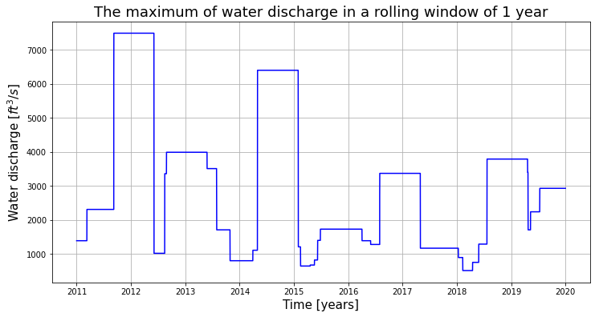

```python
plt.figure(figsize=(12,6))
plt.plot(df['date'][window_size-1:], roll_year, c='b')
plt.title("The maximum of water discharge in a rolling window of 1 year", fontsize=FS+3)
plt.xlabel('Time [years]', fontsize=FS)
plt.ylabel('Water discharge [$ft^3/s$]', fontsize=FS)
plt.grid()
plt.show()
```

## Excercise 8

How many time does it rain in a month? (Again use a rolling window function) Calculate and plot the distribution and fit with an appropriate function!

```python
window_size2 = sum(df['date'] < pd.to_datetime("1/30/2010"))
roll_month = np.lib.stride_tricks.sliding_window_view(df['water_discharge'], window_size2)
rainy_days_roll_month = np.sum(np.diff(roll_month, axis=1) >= 2, axis=1)
```

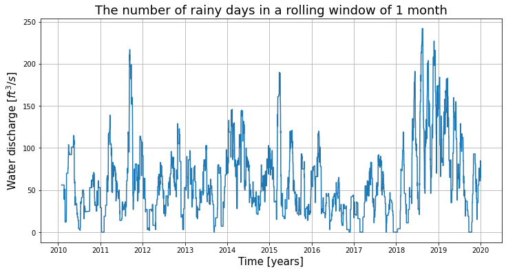

```python
plt.figure(figsize=(12,6))
plt.plot(df['date'][window_size2-1:], rainy_days_roll_month, )
plt.title("The number of rainy days in a rolling window of 1 month", fontsize=FS+3)
plt.xlabel('Time [years]', fontsize=FS)
plt.ylabel('Water discharge [$ft^3/s$]', fontsize=FS)
plt.grid()
plt.show()
```

I think that a distribution cannot be fitted to this type of time series data because the number of rainy days follows a random distribution.

## Excercise 9

Find the measuring station you used in the excercises above on the map. Find another measurement station about 100-200 kms from it and download the data! Try to estimate the typical time it takes for weather fronts to travel the distance between the two measuring stations!

The second location: [Brandywine Creek at Chadds Ford](https://waterdata.usgs.gov/monitoring-location/01481000/#parameterCode=00065&period=P7D&showMedian=false)

```python
filename = f"./data/brandywine_{''.join(start_date)}-{''.join(end_date)}.txt"

if not os.path.exists(filename):
    import requests
    url = "https://nwis.waterdata.usgs.gov/nwis/uv/"
    params = {
        "format": 'rdb',
        "site_no": '01481000',
        "parameterCd": '00065',
        "begin_date": ''.join(start_date),
        "end_date": ''.join(end_date),
        "siteStatus": 'all'
    }
    response = requests.get(url, params=params)

    with open(filename, "w") as file:
        file.write(response.text)
    df2 = pd.read_csv(filename, sep='\t', skiprows=[39], comment='#', parse_dates=['datetime'])

else:
    df2 = pd.read_csv(filename, sep='\t', skiprows=[39], comment='#', parse_dates=['datetime'])
df2.columns
```

```
Index(['agency_cd', 'site_no', 'datetime', 'tz_cd', '121679_00060',
       '121679_00060_cd', '121680_00065', '121680_00065_cd', '121681_00095',
       '121681_00095_cd', '121682_00400', '121682_00400_cd', '121683_00010',
       '121683_00010_cd', '121684_00300', '121684_00300_cd', '121686_00045',
       '121686_00045_cd', '277505_63680', '277505_63680_cd'],
      dtype='object')
```

```python
df2 = df2[['datetime', '121679_00060', '121680_00065']]
df2.dropna(inplace=True)
df2.rename(columns={'datetime':'date', '121679_00060':'water_discharge', '121680_00065':'gage_height'}, inplace=True)
df2['date'] = df2['date'].astype('datetime64[s]')
df2.head()
```

|  | date | water_discharge | gage_height |
| --- | --- | --- | --- |
| 0 | 2010-01-01 00:00:00 | 825.0 | 3.07 |
| 1 | 2010-01-01 00:15:00 | 832.0 | 3.08 |
| 2 | 2010-01-01 00:30:00 | 832.0 | 3.08 |
| 3 | 2010-01-01 00:45:00 | 838.0 | 3.09 |
| 4 | 2010-01-01 01:00:00 | 838.0 | 3.09 |

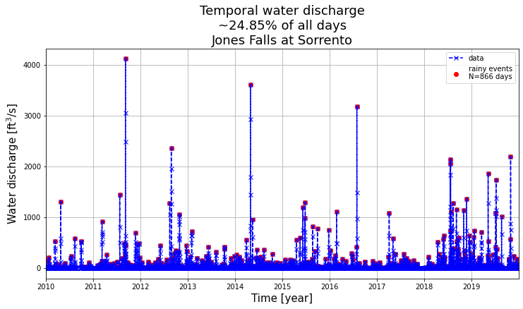

```python
t_diff_in_hours = 3 # hour

water_discharge_diff = np.round(abs(np.diff(df.water_discharge[::(t_diff_in_hours*4)])), 1)
dates_wd_diff = df.date[::(t_diff_in_hours*4)][:-1].values

dates_wd_diff_wo0 = dates_wd_diff[water_discharge_diff != 0]
# water_discharge_diff without zeros
water_discharge_diff_wo0 = water_discharge_diff[water_discharge_diff != 0]

                                                        # ˇ~~ only one peak per day
peaks = find_peaks(water_discharge_diff_wo0, height=1.7, distance=(24/t_diff_in_hours))

# Rainy days
rainy_days_pct = len(dates_wd_diff_wo0[peaks[0]])/(len(df.date)/(4*24))*100

plt.figure(figsize=(12,6))
plt.plot(dates_wd_diff_wo0, water_discharge_diff_wo0, 'x--', c='b', label='data')
plt.scatter(dates_wd_diff_wo0[peaks[0]], peaks[1]['peak_heights'], marker='o', color='r', label=f'rainy events\nN={len(dates_wd_diff_wo0[peaks[0]])} days')
plt.xlim(np.min(dates_wd_diff_wo0), np.max(dates_wd_diff_wo0))
plt.title(f'Temporal water discharge\n~{np.round(rainy_days_pct,2)}% of all days\nJones Falls at Sorrento', fontsize=FS+3)
plt.xlabel('Time [year]', fontsize=FS)
plt.ylabel('Water discharge [ft$^3/$s]', fontsize=FS)
plt.legend()
plt.grid()
plt.show()
```

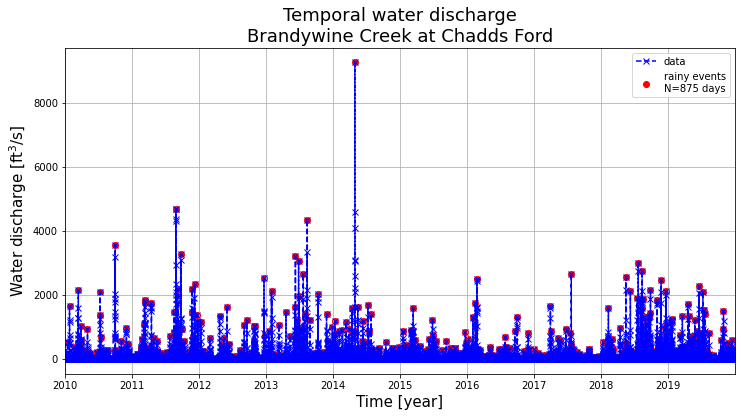

```python
t_diff_in_hours = 3 # hour

water_discharge_diff_2 = np.round(abs(np.diff(df2.water_discharge[::(t_diff_in_hours*4)])), 1)
dates_wd_diff2 = df2.date[::(t_diff_in_hours*4)][:-1].values

dates_wd_diff_wo0_2 = dates_wd_diff2[water_discharge_diff_2 != 0]
# water_discharge_diff_2 without zeros
water_discharge_diff_wo0_2 = water_discharge_diff_2[water_discharge_diff_2 != 0]

                                                                   # ˇ~~ only one peak per day
peaks_2 = find_peaks(water_discharge_diff_wo0_2, height=22, distance=(24/t_diff_in_hours))

# Rainy days
rainy_days_pct_2 = len(dates_wd_diff_wo0_2[peaks_2[0]])/(len(df.date)/(4*24))*100

plt.figure(figsize=(12,6))
plt.plot(dates_wd_diff_wo0_2, water_discharge_diff_wo0_2, 'x--', c='b', label='data')
plt.scatter(dates_wd_diff_wo0_2[peaks_2[0]], peaks_2[1]['peak_heights'], marker='o', color='r', label=f'rainy events\nN={len(dates_wd_diff_wo0_2[peaks_2[0]])} days')
plt.xlim(np.min(dates_wd_diff_wo0_2), np.max(dates_wd_diff_wo0_2))
plt.title(f'Temporal water discharge\nBrandywine Creek at Chadds Ford', fontsize=FS+3)
plt.xlabel('Time [year]', fontsize=FS)
plt.ylabel('Water discharge [ft$^3/$s]', fontsize=FS)
plt.legend()
plt.grid()
plt.show()
```

```python
rainy_events_1 = dates_wd_diff_wo0[peaks[0]]
rainy_events_2 = dates_wd_diff_wo0_2[peaks_2[0]]

if len(rainy_events_1) == len(rainy_events_2):
    print('We dont need to drop values from any list.')
else:
    print('Drop few elements from one of the list, or change the rainy events decetion criteria.')
    len_diff = len(rainy_events_1) - len(rainy_events_2)
    if len_diff > 0:
        rainy_events_1 = rainy_events_1[:len_diff]
        print(f'{abs(len_diff)} elements dropped from the first dataset')
    else:
        rainy_events_2 = rainy_events_2[:len_diff]
        print(f'{abs(len_diff)} elements dropped from the second dataset')
```

```
Drop few elements from one of the list, or change the rainy events decetion criteria.
9 elements dropped from the second dataset
```

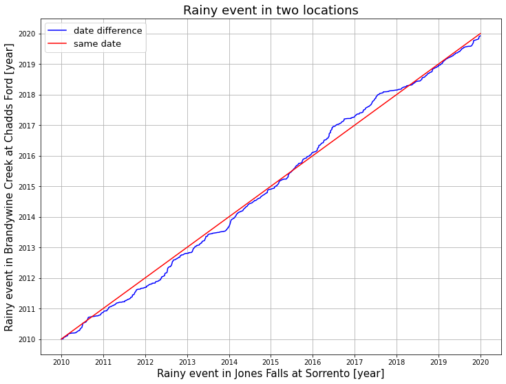

```python
plt.figure(figsize=(12,9))
plt.plot(rainy_events_1, rainy_events_2, color='b', label='date difference')
plt.plot([pd.to_datetime("1/1/2010"), pd.to_datetime("1/1/2020")], [pd.to_datetime("1/1/2010"), pd.to_datetime("1/1/2020")],  color='r', label='same date')
plt.title(f'Rainy event in two locations', fontsize=FS+3)
plt.xlabel('Rainy event in Jones Falls at Sorrento [year]', fontsize=FS)
plt.ylabel('Rainy event in Brandywine Creek at Chadds Ford [year]', fontsize=FS)
plt.legend(fontsize=FS-2)
plt.grid()
plt.show()
```

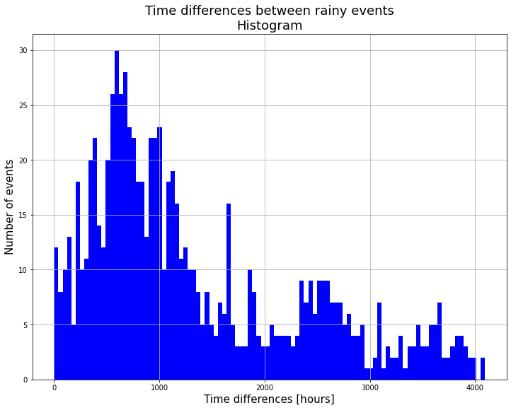

```python
hours_array = np.abs(rainy_events_1 - rainy_events_2).astype('timedelta64[h]') / np.timedelta64(1, 'h')
plt.figure(figsize=(12,9))
plt.hist(hours_array, bins=100, color='b')
plt.title(f'Time differences between rainy events\nHistogram', fontsize=FS+3)
plt.xlabel('Time differences [hours]', fontsize=FS)
plt.ylabel('Number of events', fontsize=FS)
plt.grid()
plt.show()
```

#### Second solutions:

Study only days with maximal 24 hour difference.

```python
rainy_events_1 = dates_wd_diff_wo0[peaks[0]]
rainy_events_2 = dates_wd_diff_wo0_2[peaks_2[0]]
len_re_1 = len(rainy_events_1)
len_re_2 = len(rainy_events_2)
```

```python
passed_hours_between_rainy_events = []
rainy_date = []
for i in range(len(rainy_events_1)):
    for j in range(i-30, i+30):
        if (rainy_events_1[i] - rainy_events_2[j%len_re_2]) < np.timedelta64(1, 'D'):
            hours = rainy_events_2[j].astype('datetime64[h]').astype(int) % 24
            minutes = rainy_events_2[j].astype('datetime64[m]').astype(int) % 60
            passed_hours_between_rainy_events.append(hours+minutes/60)
```

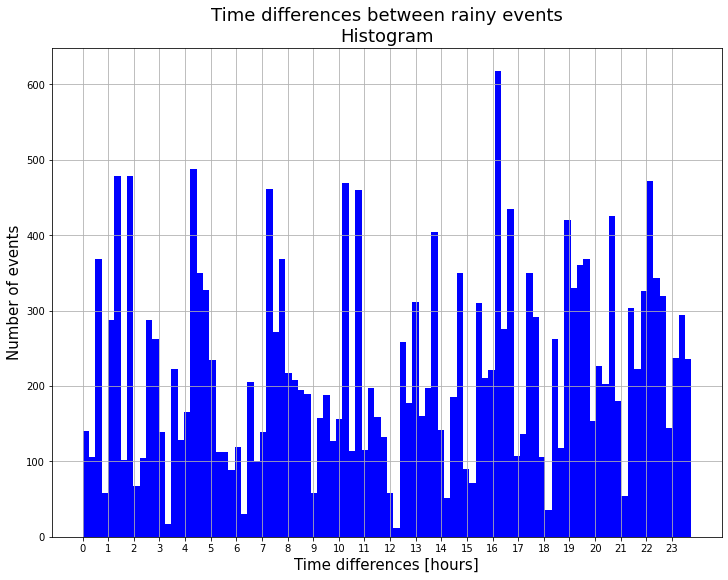

```python
plt.figure(figsize=(12,9))
plt.hist(passed_hours_between_rainy_events, bins=24*4, color='b')
plt.xticks(np.linspace(0,23,24))
plt.title(f'Time differences between rainy events\nHistogram', fontsize=FS+3)
plt.xlabel('Time differences [hours]', fontsize=FS)
plt.ylabel('Number of events', fontsize=FS)
plt.grid()
plt.show()
```

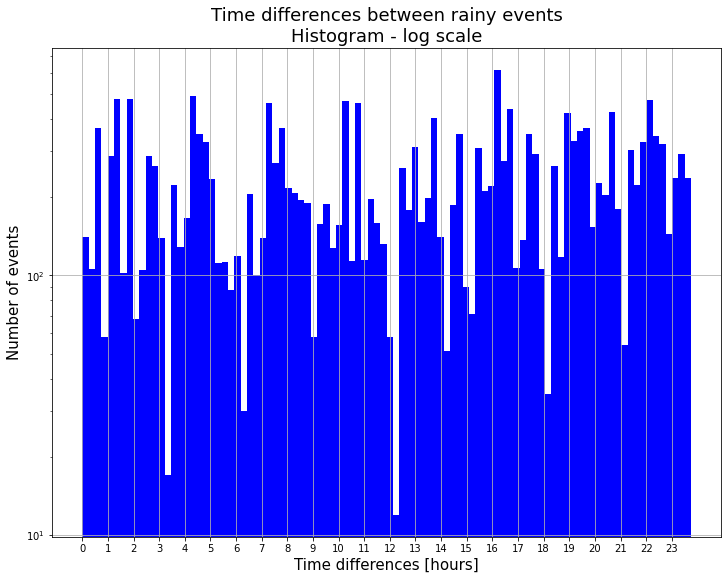

```python
plt.figure(figsize=(12,9))
plt.hist(passed_hours_between_rainy_events, bins=24*4, color='b')
plt.xticks(np.linspace(0,23,24))
plt.title(f'Time differences between rainy events\nHistogram - log scale', fontsize=FS+3)
plt.xlabel('Time differences [hours]', fontsize=FS)
plt.ylabel('Number of events', fontsize=FS)
plt.yscale('log')
plt.grid()
plt.show()
```